# kits 的模型：寫一次，導數交給 RTMB

## 0 這份教學在講什麼

kits 0.24.2 的每個估計都是一個模型。 kits 只寫模型本身：概似、門檻的方程式、訊息函數。 導數一個也不手推。 梯度、Hessian、牛頓法、隱函數的導數，都交給 RTMB 的自動微分。 這就是「模型寫一次，導數由 RTMB 給」。

這有兩個好處。 第一，公式只有一份，程式和公式可以一行一行對著讀。 第二，手推的導數容易錯，也容易和模型不同步；自動微分不會。

這份教學一節講一個模型。 每一節有四個部分：

1. 公式：模型的數學式。
2. 程式：套件裡真正的程式。 這些程式在產生這份文件時，從 `kits/R/` 的原始檔讀進來。 所以文件和程式不會不同步。
3. RTMB 做什麼：兩到四句話。
4. 對答案：一個小例子，在示範資料或模擬資料上算一次，和另一種算法比。

示範資料是套件附的 `kitm03`、`kitm36`。 其他都是模擬資料。 輸出裡沒有任何人的編號。

```r
library(kits)
library(dplyr)
library(tidyr)
library(purrr)
library(tibble)
library(ggplot2)
```

### 0.1 讀原始檔的小工具

第一個函數找出一個函數在檔案裡的行。 它用 `parse(keep.source = TRUE)` 解析整個檔案，再看每個運算式的 `srcref`。

```r
src_dir <- file.path("..", "kits", "R")

fun_range <- function(file, name) {
  exprs <- parse(file.path(src_dir, file), keep.source = TRUE)
  defined <- map_chr(as.list(exprs), \(e) if (is.call(e)) deparse(e[[2]])[1] else "")
  ref <- attr(exprs, "srcref")[[match(name, defined)]]
  c(first = with_comments(file, ref[1]), body = ref[1], last = ref[3])
}
```

函數上面連著的註解也算進來（`#` 開頭；不含 roxygen 的 `#'`）。

```r
with_comments <- function(file, first) {
  lines <- readLines(file.path(src_dir, file))
  while (first > 1 && grepl("^#(\\s|$)", lines[first - 1])) first <- first - 1
  first
}
```

第二個函數把找到的行印成 R 的程式區塊（區塊選項 `output: asis`）。

````r
show_code <- function(file, names) {
  lines <- readLines(file.path(src_dir, file))
  for (name in names) {
    r <- fun_range(file, name)
    cat(sprintf("\n```r\n# kits/R/%s，第 %d–%d 行\n", file, r[["first"]], r[["last"]]))
    cat(lines[r[["first"]]:r[["last"]]], sep = "\n")
    cat("```\n\n")
  }
}
````

對答案時，把每一個差距記下來，最後一起列表（第 10 節）。

```r
checks <- tibble(section = character(), check = character(), max_diff = numeric())
record <- function(section, check, diff) {
  checks <<- add_row(checks, section = section, check = check, max_diff = max(abs(diff)))
  max(abs(diff))
}
```

### 0.2 模型一覽

```r
models <- tribble(
  ~section, ~model, ~file, ~funs,
  "1", "PCM 核心", "pcm_core.R", c("pcm_kernel", "pcm_kernel_ad", "is_ad", "row_sum"),
  "1", "PCM 的動差", "algo.R", "algo_pcm",
  "2", "CML", "cml.R", c("cml_nll", "cml_centre", "cml_gamma_matrix", "times_item_poly"),
  "2", "CML（多項式）", "pcm_core.R", c("poly_times", "shift_cols"),
  "3", "最佳化", "cml.R", "fit_ad",
  "4", "WLE", "ability.R", c("wle_setup", "wle_parts", "wle_solve"),
  "4", "WLE（Jeffreys 眾數估計）", "algo.R", "algo_jme",
  "5", "門檻的 SE", "calibrate.R",
  c("p_at_least", "step_threshold", "threshold_jacobian", "step_thresholds"),
  "6", "ESF", "algo.R", "algo_esf",
  "7", "同齡組的潛在常態", "link_check.R", "latent_normal",
  "8", "shash 常模", "norms_shash.R", c("ad_clamp", "shash_link"),
  "8", "shash 常模（概似）", "algo.R", "algo_shash",
  "9", "訊息的斜率", "pcm_core.R", "information_slope",
  "9", "GK gamma 的 SE", "restscore.R", "gk_gamma"
)
```

每個函數的行數也從原始檔算：程式的行，和上面的註解行。

```r
count_lines <- function(file, funs) {
  r <- map(funs, \(f) fun_range(file, f))
  c(code = sum(map_dbl(r, \(x) x[["last"]] - x[["body"]] + 1)),
    comment = sum(map_dbl(r, \(x) x[["body"]] - x[["first"]])))
}
models <- models |>
  mutate(n = map2(file, funs, count_lines), code = map_dbl(n, "code"),
         comment = map_dbl(n, "comment"))
```

每個模型寫了什麼，RTMB 給了什麼：

```r
models |>
  mutate(written = c("eta、log S", "P、E、Var", "-log L（gamma 是多項式的係數）", "多項式相乘",
                     "（呼叫 RTMB）", "f = log L + 1/2 log I", "SE = sqrt(I + (I'/2I)^2) / I",
                     "sum_k (P(X >= k) - rp)^2", "gamma、P(X = x | r)", "-log L（格點積分）",
                     "參數的多項式和界", "-log f（shash）", "I(theta)", "gamma = (C - D) / (C + D)"),
         rtmb = c("logspace_add()、advector 的路", "（數值和 advector 同一段）",
                  "MakeADFun()：梯度；ADoverload()", "（錄進 CML 的 tape）",
                  "nlminb + 牛頓步（$gr、$he）", "MakeTape、$newton()", "I' 用 $jacobian()",
                  "$newton() 再 $jacobian()", "（和 CML 同一段程式）",
                  "MakeADFun、ADREPORT、sdreport", "（錄進 shash 的 tape）", "MakeADFun：梯度",
                  "$jacobian()", "$jacobian()：d gamma / d n")) |>
  transmute(節 = section, 模型 = model, 檔案 = file, 函數 = map_chr(funs, toString),
            程式行 = code, 註解行 = comment, 寫的是 = written, RTMB給的 = rtmb) |>
  mutate(across(where(is.character), \(x) gsub("$", "\\$", x, fixed = TRUE))) |>
  knitr::kable()
```

[output not shown]

```r
total_code <- sum(models$code)
total_comment <- sum(models$comment)
```

這些模型的程式加起來 338 行，註解 58 行。 其中最長的是 shash 常模的 `algo_shash()`：大部分是 cNORM 的界、起始值和收斂的判斷，概似本身只有十來行。 導數的程式：0 行。

## 1 PCM 核心

### 公式

部分給分模型（PCM；Masters, 1982）。 第 $i$ 題有 $m_i$ 個步驟，步驟參數 $\beta_{i1}, \dots, \beta_{im_i}$。

$$\eta_{ik}(\theta) = \sum_{g=1}^{k} (\theta - \beta_{ig}), \qquad \eta_{i0} = 0$$

$$P(X_i = k \mid \theta) = \frac{\exp \eta_{ik}}{S_i(\theta)}, \qquad
S_i(\theta) = \sum_{h=0}^{m_i} \exp \eta_{ih}$$

$$E_i(\theta) = \sum_k k \, P_{ik}, \qquad
\mathrm{Var}_i(\theta) = \sum_k (k - E_i)^2 P_{ik}, \qquad
M_{3,i}(\theta) = \sum_k (k - E_i)^3 P_{ik}$$

$\mathrm{Var}_i$ 就是第 $i$ 題的訊息。 這三個量之間有兩個恆等式，等一下拿來對答案：

$$\frac{d}{d\theta} \log S_i(\theta) = E_i(\theta), \qquad
\frac{d}{d\theta} E_i(\theta) = \mathrm{Var}_i(\theta)$$

### 程式

```r
show_code("pcm_core.R", c("pcm_kernel", "pcm_kernel_ad", "is_ad", "row_sum"))
# kits/R/pcm_core.R，第 19–32 行
# 一題的核心：exp(eta - 列最大值)（ex，未標準化）、列和 S、log S。列是 theta，欄是分數 0..m
pcm_kernel <- function(theta, beta_i) {
  if (is_ad(theta) || is_ad(beta_i)) {
    return(pcm_kernel_ad(theta, beta_i))
  }
  n <- length(theta)
  m <- length(beta_i)
  steps <- matrix(apply(outer(theta, beta_i, "-"), 1, cumsum), nrow = n, ncol = m, byrow = TRUE)
  eta <- cbind(0, steps)                    # eta_k = sum_{g <= k} (theta - beta_g)
  top <- if (n > 0) apply(eta, 1, max) else numeric(0)
  ex <- exp(eta - top)
  S <- rowSums(ex)
  list(ex = ex, S = S, log_S = top + log(S))
}
# kits/R/pcm_core.R，第 34–46 行
# RTMB 版：eta_k = eta_(k-1) + (theta - beta_k)（和 cumsum 同一個加法順序）；
# log S 用 logspace_add() 逐欄累加（不用列最大值），ex = exp(eta - log S)，所以 S = 1
pcm_kernel_ad <- function(theta, beta_i) {
  col <- 0 * theta + 0 * beta_i[1]          # eta_0 = 0
  eta <- cbind(col)
  log_S <- col
  for (k in seq_along(beta_i)) {
    col <- col + (theta - beta_i[k])
    eta <- cbind(eta, col)
    log_S <- RTMB::logspace_add(log_S, col)
  }
  list(ex = exp(eta - log_S), S = rep(1, length(theta)), log_S = log_S)
}
# kits/R/pcm_core.R，第 48–49 行
# x 是不是 RTMB 的 advector（自動微分中）
is_ad <- function(x) inherits(x, "advector")
# kits/R/pcm_core.R，第 51–54 行
# 列和：RTMB 的 advector 不能用 rowSums()，改用矩陣乘法；數值照舊用 rowSums()
row_sum <- function(M) {
  if (is_ad(M)) drop(M %*% rep(1, ncol(M))) else rowSums(M)
}
show_code("algo.R", "algo_pcm")
# kits/R/algo.R，第 34–45 行
algo_pcm <- function(theta, beta, third = FALSE) {
  q <- pcm_kernel(theta, beta)
  P <- q$ex / q$S
  k <- seq_len(ncol(P)) - 1
  E <- drop(P %*% k)
  dev <- outer(-E, k, "+")                  # k - E
  Var <- row_sum(P * dev^2)                 # 中央動差：極端的 theta 不會相消
  if (!is_ad(Var)) Var <- pmax(Var, 0)      # 數值的捨入不讓它小於 0（RTMB 不能比大小，也不需要）
  out <- list(P = P, E = E, Var = Var, log_S = q$log_S)
  if (third) out$M3 <- row_sum(P * dev^3)
  out
}
```

### RTMB 做什麼

輸入是數值時，走 `pcm_kernel()` 原來的路：每列減掉最大值再取 exp，數字一個位元都不變。 輸入是 RTMB 的 advector（正在錄 tape）時，走 `pcm_kernel_ad()`。 RTMB 不能對「比大小」微分，所以不減最大值，改用 `logspace_add()` 逐欄累加 $\log S$；這樣一樣不會溢位。 `row_sum()` 用矩陣乘法代替 `rowSums()`，因為 advector 不能用 `rowSums()`。

### 對答案

一題三個步驟，13 個 theta。

```r
beta_i <- c(-1, 0.3, 1.2)
theta <- seq(-3, 3, by = 0.5)
num <- kits:::pcm_kernel(theta, beta_i)
mom <- algo_pcm(theta, beta_i)
```

把 $\log S$ 錄成 tape：tape 裡走的是 `pcm_kernel_ad()`。 它的值和數值的路相同。

```r
tape_log_S <- RTMB::MakeTape(\(t) kits:::pcm_kernel(t, beta_i)$log_S, theta)
record("1", "log S：advector 的路 vs 數值的路", tape_log_S(theta) - num$log_S)
```

```
#> [1] 2.220446e-16
```

$\log S$ 的導數是 $E$。 每個 $\log S$ 只和自己的 theta 有關，所以 `sum()` 的 jacobian 就是每個 theta 的導數。

```r
d_log_S <- RTMB::MakeTape(\(t) sum(kits:::pcm_kernel(t, beta_i)$log_S), theta)
record("1", "d log S / d theta vs E", drop(d_log_S$jacobian(theta)) - mom$E)
```

```
#> [1] 4.440892e-16
```

$E$ 的導數是 $\mathrm{Var}$（題目訊息）。

```r
d_E <- RTMB::MakeTape(\(t) sum(algo_pcm(t, beta_i)$E), theta)
record("1", "d E / d theta vs Var", drop(d_E$jacobian(theta)) - mom$Var)
```

```
#> [1] 6.106227e-16
```

差距都在 1e-15 左右：捨入誤差。

## 2 CML：條件最大概似

### 公式

原始分 $r$ 是 theta 的充分統計量。 給定原始分，作答型態的機率和 theta 無關：

$$P(\mathbf{x} \mid r) = \frac{\exp\left(-\sum_i \sum_{g \le x_i} \beta_{ig}\right)}{\gamma_r}$$

$\gamma_r$ 是基本對稱函數（elementary symmetric function）。 它是一個多項式乘積的係數：

$$\gamma_r = [z^r] \prod_i \left(1 + e_{i1} z + e_{i2} z^2 + \dots + e_{im_i} z^{m_i}\right),
\qquad e_{ik} = \exp\left(-\sum_{g \le k} \beta_{ig}\right)$$

$n_{ig}$ 是這一題得到 $g$ 分以上的人數，$n_{br}$ 是題本 $b$ 原始分 $r$ 的人數。

$$-\log L = \sum_{i,g} \beta_{ig} \, n_{ig} + \sum_b \sum_r n_{br} \log \gamma_{br}$$

長的題本，$\gamma_r$ 會下溢或上溢。 所以每個題本先把 beta 減掉它的平均 $c_b$，再乘回來（數學上完全相同）：

$$\gamma_r(\beta) = e^{-r c_b} \, \gamma_r(\beta - c_b)$$

原點：所有 beta 的和是 0，寫成 $\beta = \beta_0 + A b$，只估 $b$。

### 程式

```r
show_code("cml.R", c("cml_nll", "cml_centre", "cml_gamma_matrix", "times_item_poly"))
# kits/R/cml.R，第 146–160 行
# 條件對數概似（RTMB 自動微分）：log L = -sum_ig beta_ig n_ig - sum_b sum_r n_br log gamma_br
# log gamma_r 用置中的 beta 算：gamma_r(beta) = exp(-r c) gamma_r(beta - c)，c 是這個題本的步驟的平均。
# 這樣長的題本、或固定題離原點很遠時，多項式的係數不會下溢（變成 0）或上溢（數學上完全相同）。
# 所有題本一起算（一列一個題本的矩陣 G，一欄一個原始分）：一題一題乘上它的多項式，只乘答這題的題本。
# 和一個題本一個迴圈（教學程式 cml.R 的寫法）的數學完全相同；一起算時 RTMB 記錄的速度快很多（題本多的時候）。
cml_nll <- function(inp, con) {
  design <- cml_book_design(inp)
  function(par) {
    beta <- con$beta0 + drop(con$A %*% par$b)
    centre <- cml_centre(beta, design)                                 # c_b：每個題本的步驟的平均
    G <- cml_gamma_matrix(beta, centre, inp, design)                    # gamma_br(beta - c_b)
    log_gamma <- log(G[design$cells]) - design$raw * centre[design$book]
    sum(beta * inp$n_ge) + sum(design$n * log_gamma)                    # -log L
  }
}
# kits/R/cml.R，第 162–163 行
# 置中用的 c_b：每個題本的步驟參數的平均（CML 的概似和 algo_esf() 共用這一行；RTMB 也可以微分）
cml_centre <- function(beta, design) drop(design$has_step %*% beta) / design$n_steps
# kits/R/cml.R，第 179–191 行
# gamma 的多項式，所有題本一起：G 一列一個題本，第 r + 1 欄是 z^r 的係數。
# 一開始每個題本是 1；第 i 題把答它的題本乘上 (1, exp(-(beta_i1 - c)), exp(-(beta_i1 - c) - (beta_i2 - c)), ...)：
# 乘上 z^k 的項就是整列往右移 k 欄。beta 可以是數值（algo_esf()）或 RTMB 的 advector（cml_nll()）。
cml_gamma_matrix <- function(beta, centre, inp, design) {
  "[<-" <- RTMB::ADoverload("[<-")   # 套件裡要明說：把 advector 放進數值矩陣
  G <- matrix(0, nrow(design$has_item), design$width)
  G[, 1] <- 1
  for (i in seq_along(inp$items)) {
    rows <- which(design$has_item[, i])
    G[rows, ] <- times_item_poly(G[rows, , drop = FALSE], beta[design$steps_of[[i]]], centre[rows])
  }
  G
}
# kits/R/cml.R，第 193–203 行
# 一題的多項式乘上去（這些題本）：g(z) (1 + e_1 z + e_2 z^2 + ...)，e_k = exp(-sum_{h <= k} (beta_h - c))；
# 相乘用 poly_times()（pcm_core.R），寬度不變
times_item_poly <- function(g, beta_i, centre) {
  e <- list(1)
  cum <- 0
  for (k in seq_along(beta_i)) {
    cum <- cum + (beta_i[k] - centre)
    e[[k + 1]] <- exp(-cum)
  }
  poly_times(g, e, ncol(g))
}
show_code("pcm_core.R", c("poly_times", "shift_cols"))
# kits/R/pcm_core.R，第 79–88 行
# 多項式相乘，一列一個多項式（第 j 欄是 z^(j - 1) 的係數）：g(z) sum_k coef[[k + 1]] z^k，留 width 欄；
# 乘上 z^k 就是整列往右移 k 欄。CML 的 gamma（times_item_poly()；g 可以是 RTMB 的 advector）和
# algo_lw() 共用。每一項乘完馬上加：tape 的順序和以前相同，CML 的估計值一個位元都不變
poly_times <- function(g, coef, width = ncol(g) + length(coef) - 1) {
  out <- shift_cols(g, 0, width) * coef[[1]]
  for (k in seq_along(coef)[-1] - 1) {
    out <- out + shift_cols(g, k, width) * coef[[k + 1]]
  }
  out
}
# kits/R/pcm_core.R，第 90–94 行
# g(z) z^k：整列往右移 k 欄（左邊補 0），留 width 欄（多的截掉，不夠的補 0）
shift_cols <- function(g, k, width) {
  keep <- min(ncol(g), width - k)
  cbind(matrix(0, nrow(g), k), g[, seq_len(keep), drop = FALSE], matrix(0, nrow(g), width - k - keep))
}
```

### RTMB 做什麼

`cml_nll()` 只寫 $-\log L$。 `RTMB::MakeADFun()` 把它錄成 tape，給出 `obj$fn`、梯度 `obj$gr` 和 Hessian `obj$he`。 `cml_gamma_matrix()` 把 advector 放進數值矩陣 `G`，這要 `RTMB::ADoverload("[<-")` 明說。 多項式相乘的 `poly_times()` 是普通的 R 程式；RTMB 錄下每一個加法和乘法。

### 對答案

先看多項式相乘：$(1 + 2z)(1 + 3z) = 1 + 5z + 6z^2$。

```r
kits:::poly_times(matrix(c(1, 2), nrow = 1), list(1, 3))
```

```
#>      [,1] [,2] [,3]
#> [1,]    1    5    6
```

模擬五題、400 人；前 100 人沒答第 5 題，所以有兩個題本。

```r
betas <- list(a1 = c(-1, 0), a2 = c(0, 1), a3 = 0.5, a4 = -0.5, a5 = c(-0.5, 0.8))
set.seed(1)
X <- kits_sim(rnorm(400), betas, seed = 1)
X[1:100, "a5"] <- NA
item_sim <- kits_item(X)
```

用校準留下的充分統計量，做出同一個 $-\log L$，再交給 RTMB。

```r
inp <- kits:::cml_inputs(item_sim$stats)
con <- kits:::cml_constraint(inp, NULL)
nll <- kits:::cml_nll(inp, con)
obj <- RTMB::MakeADFun(nll, list(b = numeric(ncol(con$A))), silent = TRUE)
length(obj$par)
```

```
#> [1] 7
```

在任意一點，RTMB 的梯度和中央差分比。

```r
central_diff <- function(f, p, h = 1e-5) {
  map_dbl(seq_along(p), \(j) {
    e <- replace(numeric(length(p)), j, h)
    (f(p + e) - f(p - e)) / (2 * h)
  })
}
```

```r
p <- seq(-0.5, 0.5, length.out = length(obj$par))
record("2", "CML 梯度：RTMB vs 中央差分", obj$gr(p) - central_diff(obj$fn, p))
```

```
#> [1] 1.203006e-08
```

差距是 1e-8 左右：這是中央差分本身的誤差（$h^2$ 和捨入），不是 RTMB 的。

## 3 一個最佳化：`fit_ad()`

### 公式

CML 和第 7 節的潛在常態都用同一個最佳化。 先用梯度走準牛頓法（`nlminb`），再用精確的 Hessian 走幾步牛頓法：

$$b^{(t+1)} = b^{(t)} - H(b^{(t)})^{-1} \, g(b^{(t)})$$

最後一點的 Hessian 的反矩陣就是共變異矩陣：

$$\widehat{\mathrm{Var}}(\hat\beta) = A \, H^{-1} A^\top$$

### 程式

```r
show_code("cml.R", "fit_ad")
# kits/R/cml.R，第 225–261 行
# 一個 RTMB 模型的最佳化（內部用；CML、同齡線的潛在常態共用）。
# obj 是 RTMB::MakeADFun() 的結果：模型只寫 -log L，梯度 obj$gr 和 Hessian obj$he 都由 RTMB 自動微分。
# 1. nlminb 只用梯度（準牛頓法；參數多時每一步也很快）。
# 2. 再用精確的 Hessian 走牛頓步 par - H^-1 g：nlminb 在很嚴的容許誤差下常提早停（false convergence），
#    牛頓步才走到最大值。-log L 沒有變大（超過捨入誤差 1e-9 + 1e-12 |-log L|）才走，最多 max_newton 步，
#    步子小於 1e-10 就停（最後的 Hessian 是走這一步前算的，差別小到可以忽略）。Hessian 最花時間，所以只算幾次。
# 走太遠溢位時，目標函數給很大的值、梯度的 NaN 給 0，讓 nlminb 退回來。
# 回傳 par、value（-log L）、hessian（最後一點），和收斂的紀錄 convergence、message、max_gradient、hessian_pd
fit_ad <- function(obj, max_newton = 5) {
  fn <- function(p) {
    v <- obj$fn(p)
    if (is.finite(v)) v else 1e300
  }
  gr <- function(p) {
    g <- obj$gr(p)
    g[!is.finite(g)] <- 0
    g
  }
  opt <- stats::nlminb(obj$par, fn, gr, control = list(rel.tol = 1e-14, eval.max = 2000, iter.max = 2000))
  par <- opt$par
  value <- obj$fn(par)
  H <- obj$he(par)
  for (step in seq_len(max_newton)) {
    if (any(!is.finite(H)) || rcond(H) < 1e-14) break   # 奇異的 Hessian：不走牛頓步（估不出來的設計在前面就停下來了）
    delta <- tryCatch(solve(H, drop(obj$gr(par))), error = function(e) NULL)
    if (is.null(delta)) break
    par_new <- par - delta
    v_new <- obj$fn(par_new)
    if (!is.finite(v_new) || v_new > value + 1e-9 + 1e-12 * abs(value)) break
    par <- par_new
    value <- v_new
    if (max(abs(delta)) < 1e-10) break
    H <- obj$he(par)
  }
  list(par = par, value = value, hessian = H, convergence = opt$convergence, message = opt$message,
       max_gradient = max(abs(obj$gr(par))), hessian_pd = is_pd(H))
}
```

### RTMB 做什麼

`obj$gr` 和 `obj$he` 都由 RTMB 自動微分。 `nlminb` 在很嚴的容許誤差下常提早停，回傳的代碼不是 0；精確 Hessian 的牛頓步才走到最大值。 Hessian 最花時間，所以只算幾次。

### 對答案

用第 2 節的 `obj`。

```r
fit <- kits:::fit_ad(obj)
fit[c("convergence", "message", "max_gradient", "hessian_pd")]
```

```
#> $convergence
#> [1] 1
#>
#> $message
#> [1] "singular convergence (7)"
#>
#> $max_gradient
#> [1] 2.842171e-14
#>
#> $hessian_pd
#> [1] TRUE
```

`nlminb` 自己沒有宣告收斂（代碼 1，訊息「singular convergence (7)」）。 但牛頓步之後，最大梯度是 2.8e-14，Hessian 正定：已經在最大值。

估計值和 `kits_item()` 的完全相同（這就是它用的程式）。

```r
beta_hat <- drop(con$beta0 + con$A %*% fit$par)
record("3", "beta：fit_ad() vs kits_item()", beta_hat - item_sim$fit$coef$beta)
```

```
#> [1] 0
```

RTMB 的 Hessian 和梯度的中央差分比。

```r
H_cd <- map(seq_along(fit$par), \(j) central_diff(\(q) obj$gr(q)[j], fit$par)) |>
  do.call(what = rbind)
record("3", "CML Hessian：RTMB vs 梯度的中央差分", fit$hessian - H_cd)
```

```
#> [1] 6.451373e-09
```

SE 是 $A H^{-1} A^\top$ 的對角線開根號，和 `kits_item()` 的 `SE_beta` 相同。

```r
V <- con$A %*% solve(fit$hessian) %*% t(con$A)
record("3", "SE_beta：A H^-1 A' vs kits_item()", sqrt(diag(V)) - item_sim$fit$coef$SE_beta)
```

```
#> [1] 0
```

## 4 WLE：加權概似估計

### 公式

Warm（1989）的 WLE 最大化加權概似：

$$f(\theta) = \log L(\theta) + \tfrac{1}{2} \log I(\theta), \qquad
\log L(\theta) = r\theta - \sum_i \log S_i(\theta), \qquad
I(\theta) = \sum_i \mathrm{Var}_i(\theta)$$

$\log S_i$ 和 $\mathrm{Var}_i$ 來自第 1 節的核心。 原始分是充分統計量，所以 WLE 只和「題目組合 × 原始分」有關。 起始值和 TAM 相同：

$$\theta_0 = \bar\beta + \log \frac{r + 0.5}{R - r + 1}$$

### 程式

```r
show_code("ability.R", c("wle_setup", "wle_parts", "wle_solve"))
# kits/R/ability.R，第 430–439 行
# 每題的步驟參數（beta_of：一題一個向量，有名字）、答這題的組合，和起始值 theta0
wle_setup <- function(beta_of, sets, raw) {
  max_raw <- map_dbl(sets, \(s) sum(lengths(beta_of[s])))
  mean_beta <- map_dbl(sets, \(s) mean(unlist(beta_of[s])))
  items <- sort(unique(unlist(sets)))
  rows_of <- map(items, \(i) which(map_lgl(sets, \(s) i %in% s)))
  names(rows_of) <- items
  list(beta_of = beta_of[items], rows_of = rows_of,
       theta0 = mean_beta + log((raw + 0.5) / (max_raw - raw + 1)))
}
# kits/R/ability.R，第 415–428 行
# 每個組合在 theta 的 sum_i log S_i 和 I = sum_i Var_i：一題一題加到答這題的組合上
# （theta 可以是數值或 RTMB 的 advector）
wle_parts <- function(theta, setup) {
  "[<-" <- RTMB::ADoverload("[<-")   # 套件裡要明說：advector 放進數值向量
  log_S <- numeric(length(theta))
  info <- numeric(length(theta))
  for (i in names(setup$rows_of)) {
    rows <- setup$rows_of[[i]]
    m <- algo_pcm(theta[rows], setup$beta_of[[i]])
    log_S[rows] <- log_S[rows] + m$log_S
    info[rows] <- info[rows] + m$Var
  }
  list(log_S = log_S, info = info)
}
# kits/R/ability.R，第 380–387 行
# 組合 idx 的 WLE：-f 加起來做成 RTMB 的 tape，tape$newton() 從 start 一次解出來
# （RTMB 解不出來時回傳 NaN；一個組合失敗時整批都是 NaN）
wle_solve <- function(setup, raw, idx, start = setup$theta0[idx]) {
  sub <- wle_subset(setup, idx)
  neg_f <- \(d) -sum(wle_f(start + d, sub, raw[idx]))   # d = theta - start
  solve_f <- RTMB::MakeTape(neg_f, numeric(length(idx)))$newton(seq_along(idx), grad_tol = 1e-12)
  start + suppressWarnings(solve_f(numeric(0)))
}
show_code("algo.R", "algo_jme")
# kits/R/algo.R，第 186–207 行
algo_jme <- function(betas, raw = 0:sum(lengths(betas)),
                     items = rep(list(names(betas)), length(raw))) {
  # JME：theta = argmax f(theta)，f = log L(theta) + 1/2 log I(theta)（PCM 時等於 Warm 的 WLE）；原始分是充分統計量，
  # log L = r theta - sum_i log S_i(theta)，I = sum_i Var_i(theta)（algo_pcm()）。每列一個 theta，
  # 所有列的 -f 加起來是一個 RTMB tape，tape$newton() 一次解出來（wle_solve()，ability.R）。
  # f 有兩個高點時取高的（f 的值決定）；一樣高時取 theta 小的。
  # SE = 1 / sqrt(I(theta))：WLE 的漸近 SE（Warm, 1989）
  setup <- wle_setup(betas, items, raw)
  n <- length(raw)
  if (n == 0) {
    return(data.frame(theta = numeric(0), se = numeric(0)))
  }
  theta <- wle_solve(setup, raw, seq_len(n))
  grid <- wle_grid(setup, raw)   # 格點上的 f 高出 1e-8 以上（或解不出來）的組合：從格點再解
  up <- which(!(wle_f(theta, setup, raw) >= grid$f - 1e-8))
  if (length(up) > 0) theta[up] <- wle_solve(setup, raw, up, grid$theta[up])
  if (any(!is.finite(theta))) {
    kits_abort("The WLE did not converge for ", sum(!is.finite(theta)), " item pattern x raw score combination(s).",
               class = "kits_error_fit")
  }
  data.frame(theta = theta, se = 1 / sqrt(wle_parts(theta, setup)$info))   # SE = 1 / sqrt(I(theta))
}
```

### 對答案

示範資料：`kitm03` 的語言題，6 個月以下的波次。 先校準，再計分。

```r
lan_long <- kitm03$responses |>
  filter(domain == "lan", wave_m <= 6)
resp <- kits_resp(lan_long)
item <- kits_item(resp, scale = "lan M03")
scores <- kits_subj(resp, item)
```

每個人答了哪些題，接到分數表上，留下不重複的「題目組合 × 原始分」。

```r
sets_of <- lan_long |>
  summarise(set = list(sort(unique(item_id))), .by = visit_id)
combos <- as.data.frame(scores) |>
  left_join(sets_of, by = "visit_id") |>
  distinct(pattern_id, raw, theta, se, set)
nrow(combos)
```

```
#> [1] 20
```

用套件的 `wle_setup()` 和 `wle_solve()` 直接解一次。 它就是 `kits_subj()` 用的牛頓法，所以完全相同。

```r
parms <- kits:::param_frame(item)
setup <- kits:::wle_setup(kits:::betas_by_item(parms), combos$set, combos$raw)
theta_newton <- kits:::wle_solve(setup, combos$raw, seq_len(nrow(combos)))
record("4", "WLE：牛頓法 vs kits_subj()", theta_newton - combos$theta)
```

```
#> [1] 0
```

再換一個不用導數的方法：`optimize()` 直接找 $f$ 的最大值。

```r
f_wle <- function(t, j) {
  parts <- kits:::wle_parts(t, kits:::wle_subset(setup, j))
  combos$raw[j] * t - parts$log_S + 0.5 * log(parts$info)
}
theta_opt <- map_dbl(seq_len(nrow(combos)), \(j) {
  optimize(f_wle, c(-15, 15), j = j, maximum = TRUE, tol = 1e-10)$maximum
})
record("4", "WLE：kits_subj() vs optimize()", theta_opt - combos$theta)
```

```
#> [1] 2.50542e-08
```

差距是 `optimize()` 的容許誤差（黃金分割法只到約 1e-8）。

SE 的 $I'$ 改用中央差分，代入 Warm 的公式。

```r
info_at <- function(t, j) kits:::wle_parts(t, kits:::wle_subset(setup, j))$info
warm_se <- function(j, h = 1e-5) {
  t <- combos$theta[j]
  I <- info_at(t, j)
  I1 <- (info_at(t + h, j) - info_at(t - h, j)) / (2 * h)
  sqrt(I + (I1 / (2 * I))^2) / I
}
se_cd <- map_dbl(seq_len(nrow(combos)), warm_se)
record("4", "WLE 的 SE：RTMB 的 I' vs 中央差分", se_cd - combos$se)
```

```
#> [1] 0.3223086
```

## 5 門檻和它的 SE

### 公式

第 $k$ 個步驟的 Thurstonian 門檻 $\tau_k$：能力在 $\tau_k$ 的人，得到 $k$ 分以上的機率剛好是 rp（預設 0.5）。

$$P(X_i \ge k \mid \tau_k) = \mathrm{rp}, \qquad k = 1, \dots, m_i$$

門檻是 beta 的隱函數。 SE 用 delta method：

$$\mathrm{SE}(\tau) = \sqrt{\mathrm{diag}\left(J \, V_\beta \, J^\top\right)}, \qquad
J = \frac{\partial \tau}{\partial \beta}$$

$J$ 不手推。 kits 把門檻寫成一個最小化：

$$\tau(\beta) = \arg\min_{\theta_1, \dots, \theta_m} \sum_k \left(P(X_i \ge k \mid \theta_k) - \mathrm{rp}\right)^2$$

### 程式

```r
show_code("calibrate.R", c("p_at_least", "step_threshold", "threshold_jacobian", "step_thresholds"))
# kits/R/calibrate.R，第 1–7 行
# PCM 下，能力 theta 的人在一題得到 k 分以上的機率（內部用，給門檻和它的 SE）。
# theta 可以是向量，theta 和 betas 也可以是 RTMB 的 advector。類別機率來自 pcm_kernel()（pcm_core.R）：P(X >= k) = 第 k..m 欄的和 / 列和
p_at_least <- function(theta, betas, k) {
  abort_if(k < 1 || k > length(betas), "`k` must be between 1 and the number of steps (", length(betas), ").")
  q <- pcm_kernel(theta, betas)
  row_sum(q$ex[, (k + 1):(length(betas) + 1), drop = FALSE]) / q$S
}
# kits/R/calibrate.R，第 9–13 行
# 一題一個步驟的門檻（Thurstonian threshold；內部用）：一個能力值，在這個能力得到 k 分以上的機率
# 剛好是 rp（預設 .5，RP50）。uniroot() 解 P(X >= k | theta) = rp（不用導數）。回傳 c(thr = )
step_threshold <- function(betas, k = 1, rp = 0.5) {
  c(thr = stats::uniroot(function(t) p_at_least(t, betas, k) - rp, c(-40, 40), tol = 1e-10)$root)
}
# kits/R/calibrate.R，第 50–65 行
# 門檻對步驟參數的導數（一列一個門檻，一欄一個 beta），不用手推：
# 門檻是 P(X >= k | theta_k) = rp 的解，寫成對 theta_1..theta_m 的最小化 sum_k (P(X >= k | theta_k) - rp)^2；
# RTMB 的 tape$newton() 把它變成「beta -> 門檻」的 tape（從 uniroot() 的解出發），
# 這個 tape 的 jacobian 就是 d thr / d beta（隱函數的微分由 RTMB 做）
threshold_jacobian <- function(betas, thr, rp) {
  m <- length(betas)
  gap <- function(x) {
    theta <- x[seq_len(m)]
    beta <- x[m + seq_len(m)]
    total <- 0
    for (k in seq_len(m)) total <- total + (p_at_least(theta[k], beta, k) - rp)^2
    total
  }
  solve_thr <- RTMB::MakeTape(gap, c(thr, betas))$newton(seq_len(m), grad_tol = 1e-14)
  matrix(solve_thr$jacobian(betas), m, m)
}
# kits/R/calibrate.R，第 39–48 行
# 一題每個步驟的門檻和 SE（V 是這題步驟參數的共變異矩陣；NULL 時 SE 是 NA）。
# SE：delta method sqrt(J V t(J))，J = d thr / d beta 交給 RTMB（threshold_jacobian()）
step_thresholds <- function(betas, V = NULL, rp = 0.5) {
  thr <- map_dbl(seq_along(betas), \(k) step_threshold(betas, k, rp)[["thr"]])
  if (is.null(V)) {
    return(data.frame(thr = thr, thr_se = NA_real_))
  }
  J <- threshold_jacobian(betas, thr, rp)
  data.frame(thr = thr, thr_se = sqrt(pmax(rowSums((J %*% V) * J), 0)))
}
```

### RTMB 做什麼

門檻本身用 `uniroot()` 找（不用導數）。 `threshold_jacobian()` 把平方和錄成 tape，`$newton(seq_len(m))` 對前 $m$ 個變數（門檻）求解。 結果是一個新的 tape：輸入 beta，輸出門檻。 它的 `$jacobian()` 就是 $J$；隱函數的微分由 RTMB 做。

### 對答案

第 4 節示範資料的第一題（三個步驟）。

```r
one <- filter(item$thresholds, item_id == item$thresholds$item_id[1])
thr <- kits:::step_thresholds(one$beta)$thr
J <- kits:::threshold_jacobian(one$beta, thr, 0.5)
```

$J$ 和中央差分比：把每個 beta 推一點點，用 `uniroot()` 重解門檻。

```r
thr_of <- \(b) kits:::step_thresholds(b)$thr
J_cd <- map(seq_along(one$beta), \(j) {
  e <- replace(numeric(length(one$beta)), j, 1e-5)
  (thr_of(one$beta + e) - thr_of(one$beta - e)) / 2e-5
}) |>
  do.call(what = cbind)
record("5", "門檻的 jacobian：RTMB vs 中央差分", J - J_cd)
```

```
#> [1] 2.834633e-11
```

delta method 的 SE 和 `kits_item()` 的 `thr_se` 相同。

```r
rows <- which(item$fit$coef$item_id == one$item_id[1])
V_i <- item$fit$est$acov.beta[rows, rows]
record("5", "thr_se：J V J' vs kits_item()", sqrt(diag(J %*% V_i %*% t(J))) - one$thr_se)
```

```
#> [1] 1.387779e-17
```

## 6 ESF：給定原始分的條件分布

### 公式

第 2 節的 $\gamma_r$，拿掉第 $i$ 題的乘積記成 $\gamma^{(-i)}_r$。

$$P(X_i = x \mid r) = \frac{e_{ix} \, \gamma^{(-i)}_{r - x}}{\gamma_r}$$

theta 消掉了。 條件適配和題目–其餘分數（第 9 節）都用它。

$\log \gamma_r$ 對 beta 的導數也是一個機率：

$$\frac{\partial \log \gamma_r}{\partial \beta_{ig}} = -P(X_i \ge g \mid r)$$

### 程式

```r
show_code("algo.R", "algo_esf")
# kits/R/algo.R，第 64–97 行
algo_esf <- function(betas) {
  # gamma 用 CML 的 cml_book_design() 和 cml_gamma_matrix()（cml.R）算：第 1 個「題本」是整個組合，
  # 第 1 + i 個是拿掉第 i 題的組合；所有列用同一個置中 c（整個組合的步驟平均），所以可以互相除
  items <- names(betas)
  n <- length(items)
  m <- unname(lengths(betas))
  beta <- unlist(betas, use.names = FALSE)
  inp <- list(items = items, m = m, step_item = rep(items, m),
              book_items = c(list(seq_len(n)), map(seq_len(n), \(i) seq_len(n)[-i])))
  design <- cml_book_design(inp)
  c_all <- cml_centre(beta, design)[1]   # CML 的 c_b（整個組合）：和 cml_nll() 同一個函數
  centre <- rep(c_all, n + 1)
  # 第 1 列 gamma(beta - c)；第 1 + i 列 gamma^(-i)(beta - c)
  G <- cml_gamma_matrix(beta, centre, inp, design)
  top <- sum(m)
  r <- 0:top
  # CML 的 log gamma_br：gamma_r(beta) = exp(-r c) gamma_r(beta - c)
  log_gamma <- log(G[1, ]) - r * c_all
  log_rest <- log(G[-1, , drop = FALSE]) - rep(r, each = n) * c_all
  rownames(log_rest) <- items
  prob <- map(seq_len(n), \(j) esf_item_prob(betas[[j]], c_all, G[1 + j, ], G[1, ], m[j], top))
  names(prob) <- items
  expected <- vapply(prob, \(P) drop(P %*% (seq_len(ncol(P)) - 1)), numeric(top + 1))
  variance <- vapply(seq_len(n), \(j) {
    P <- prob[[j]]
    rowSums(P * outer(expected[, j], seq_len(ncol(P)) - 1, \(e, x) (x - e)^2))
  }, numeric(top + 1))
  free <- vapply(m, \(mj) pmax(0, r - (top - mj)) < pmin(mj, r), logical(top + 1))
  dim(expected) <- dim(variance) <- dim(free) <- c(top + 1, n)
  colnames(expected) <- colnames(variance) <- colnames(free) <- items
  list(items = items, m = m, max_score = top, centre = c_all, log_gamma = log_gamma,
       log_gamma_rest = log_rest, prob = prob, expected = expected, variance = variance,
       free = free)
}
```

### RTMB 做什麼

`algo_esf()` 本身是數值計算，不需要導數。 但它不是第二份實作：$\gamma$ 直接用 CML 的 `cml_book_design()` 和 `cml_gamma_matrix()`。 在 CML 裡，同一段程式被 RTMB 錄成 tape，微分就穿過這個多項式卷積。 所以 ESF 和 CML 的 $\gamma$ 一個位元都不差。

### 對答案

四題，所有作答型態都列出來（3 × 3 × 2 × 2 = 36 種），直接加總。

```r
beta_of <- list(a1 = c(-1, 0), a2 = c(0, 1), a3 = 0.5, a4 = -0.5)
esf <- algo_esf(beta_of)
grid <- expand.grid(map(beta_of, \(b) 0:length(b)))
w <- exp(-rowSums(map2_dfc(grid, beta_of, \(x, b) c(0, cumsum(b))[x + 1])))
gamma_brute <- tapply(w, rowSums(grid), sum)
record("6", "log gamma：algo_esf() vs 全部列舉", esf$log_gamma - log(gamma_brute))
```

```
#> [1] 0
```

條件分布：原始分 3 時，第 1 題的分數。

```r
p_brute <- map_dbl(0:2, \(x) sum(w[rowSums(grid) == 3 & grid$a1 == x]) / gamma_brute[["3"]])
record("6", "P(X_1 = x | r = 3) vs 全部列舉", p_brute - esf$prob$a1[4, ])
```

```
#> [1] 5.551115e-17
```

最後讓 RTMB 穿過 `cml_gamma_matrix()` 對 beta 微分，和 $-P(X_i \ge g \mid r)$ 比。 置中 $c = 0$ 時，$G$ 的第一列就是 $\gamma_r$。

```r
m <- lengths(beta_of)
inp4 <- list(items = names(beta_of), m = unname(m), step_item = rep(names(beta_of), m),
             book_items = list(seq_along(beta_of)))
design4 <- kits:::cml_book_design(inp4)
log_gamma <- \(b) log(kits:::cml_gamma_matrix(b, 0, inp4, design4)[1, ])
J_gamma <- RTMB::MakeTape(log_gamma, unlist(beta_of))$jacobian(unlist(beta_of))
```

```r
at_least <- map(esf$prob, \(P) t(apply(P, 1, \(p) rev(cumsum(rev(p)))))[, -1, drop = FALSE])
record("6", "d log gamma / d beta vs -P(X >= g | r)", J_gamma + do.call(cbind, at_least))
```

```
#> [1] 2.220446e-16
```

## 7 連結檢查的潛在常態

### 公式

`kits_link_check()` 比較兩個世代在同一個波次的能力分佈。 題目參數固定在自己的校準，能力分佈是 $N(\mu, \sigma^2)$，用邊際最大概似估 $\mu$、$\sigma$。 原始分是充分統計量，所以每個人的邊際概似只和「題目組合 × 原始分」有關：

$$L_p = \int \exp\left(r_p \theta - \sum_{i \in b_p} \log S_i(\theta)\right) \phi(\theta; \mu, \sigma) \, d\theta$$

積分用固定的格點 $z_q$（-6 到 6，121 點），$\theta_q = \mu + \sigma z_q$：

$$\log L_p \approx \log \sum_q \exp\left(r_p \theta_q - \sum_i \log S_i(\theta_q) + \log w_q\right)$$

參數是 $\mu$ 和 $\log \sigma$。

### 程式

```r
show_code("link_check.R", "latent_normal")
# kits/R/link_check.R，第 192–230 行
# 一群孩子（一個世代的一個波次）的能力分佈 N(mu, sigma^2)：題目參數固定在自己的校準，邊際最大概似（RTMB）。
# PCM 的原始分是充分統計量，所以每個人的邊際概似只和「題目組合 x 原始分」有關：
#   L_p = integral exp(r_p theta - sum_{i in b_p} log S_i(theta)) phi(theta; mu, sigma) d theta（作答型態的常數項不影響 mu、sigma）
# log S_i(theta) 是 PCM 的核心 pcm_kernel()（R/pcm_core.R）算的。
# 積分用固定的標準常態格點 z（-6 到 6，121 點），theta = mu + sigma z；log sum exp 用 RTMB 的 logspace_add()。
# 只寫 -log L：梯度、Hessian 由 RTMB 給（fit_ad()），sd = exp(log sd) 的 SE 由 sdreport() 給。
latent_normal <- function(resp, parms) {
  betas <- betas_by_item(parms)
  persons <- person_sets(resp)
  combos <- summarise(persons, n = n(), .by = c(set, raw))   # 每個「題目組合 x 原始分」一列，n 是人數
  items_of <- map(combos$set, set_items)
  r <- combos$raw
  n <- combos$n
  z <- seq(-6, 6, length.out = 121)
  log_w <- stats::dnorm(z, log = TRUE) - log(sum(stats::dnorm(z)))
  nll <- function(par) {
    th <- par$mu + exp(par$log_sd) * z
    log_s <- map(betas, \(b) pcm_kernel(th, b)$log_S)            # log S_i(theta)，一題一個向量
    ll <- 0
    for (j in seq_along(r)) {
      v <- r[j] * th + log_w
      for (i in items_of[[j]]) v <- v - log_s[[i]]
      lse <- v[1]
      for (q in seq_along(z)[-1]) lse <- RTMB::logspace_add(lse, v[q])   # log sum_q exp(v_q)
      ll <- ll + n[j] * lse
    }
    RTMB::ADREPORT(exp(par$log_sd))
    -ll
  }
  wle <- add_wle(persons, parms)$theta   # 每個人的 WLE（起始值用；kits_subj() 的程式）
  start <- list(mu = mean(wle), log_sd = log(max(stats::sd(wle), 0.1)))
  obj <- RTMB::MakeADFun(nll, start, silent = TRUE)
  fit <- fit_ad(obj)
  rep <- RTMB::sdreport(obj, par.fixed = fit$par, hessian.fixed = fit$hessian)
  par <- unname(fit$par)
  c(n = nrow(persons), mean = par[1], sd = exp(par[2]), se_mean = sqrt(rep$cov.fixed[1, 1]),
    se_sd = summary(rep, "report")[1, "Std. Error"],
    convergence = if (fit$max_gradient <= 1e-4 && isTRUE(fit$hessian_pd)) 0 else 1)   # 和 kits_item() 同一個標準
}
```

### RTMB 做什麼

`log sum exp` 用 `RTMB::logspace_add()` 逐點累加，不會溢位，也可以微分。 `MakeADFun()` 給梯度和 Hessian，交給第 3 節的 `fit_ad()`。 `ADREPORT(exp(par$log_sd))` 宣告 $\sigma$ 是要報告的量；`sdreport()` 用 delta method 給它的 SE。

### 對答案

模擬六題、500 人，能力是 $N(0.5, 1.2^2)$。 題目參數用真值，所以 $\hat\sigma$ 應該接近 1.2。

```r
betas6 <- list(a1 = c(-1, 0), a2 = c(0, 1), a3 = 0.5, a4 = -0.5, a5 = c(-0.5, 0.8), a6 = 1.5)
set.seed(3)
X6 <- kits_sim(rnorm(500, 0.5, 1.2), betas6, seed = 2)
parms6 <- tibble(item_id = rep(names(betas6), lengths(betas6)),
                 item_score = sequence(lengths(betas6)), beta = unlist(betas6, use.names = FALSE))
```

```r
resp6 <- as_tibble(X6, rownames = "visit_id") |>
  pivot_longer(-visit_id, names_to = "item_id", values_to = "item_score")
ln <- kits:::latent_normal(resp6, as.data.frame(parms6))
round(ln, 4)
```

```
#>           n        mean          sd     se_mean       se_sd convergence
#>    500.0000      0.4634      1.1668      0.0630      0.0625      0.0000
```

用 base R 照公式重寫一次 $-\log L$（不用 kits 的核心），再用 `optim()` 估。

```r
z <- seq(-6, 6, length.out = 121)
log_w <- dnorm(z, log = TRUE) - log(sum(dnorm(z)))
log_S_base <- function(th, b) {
  eta <- outer(th, 0:length(b)) - rep(c(0, cumsum(b)), each = length(th))
  log(rowSums(exp(eta)))
}
raw_n <- count(tibble(raw = rowSums(X6)), raw)
```

```r
nll_base <- function(p) {
  th <- p[1] + exp(p[2]) * z
  ls <- reduce(map(betas6, \(b) log_S_base(th, b)), `+`)
  -sum(raw_n$n * map_dbl(raw_n$raw, \(r) log(sum(exp(r * th - ls + log_w)))))
}
opt <- optim(c(0, 0), nll_base, method = "BFGS", control = list(reltol = 1e-14))
record("7", "mu, sigma：kits vs base R optim()",
       c(opt$par[1] - ln[["mean"]], exp(opt$par[2]) - ln[["sd"]]))
```

```
#> [1] 9.889681e-08
```

SE 和 `optimHess()` 的數值 Hessian 比；$\sigma$ 的 SE 用 delta method $\sigma \cdot \mathrm{SE}(\log\sigma)$。

```r
V_ln <- solve(optimHess(c(ln[["mean"]], log(ln[["sd"]])), nll_base))
record("7", "SE(mu)、SE(sigma)：sdreport() vs 數值 Hessian",
       c(sqrt(V_ln[1, 1]) - ln[["se_mean"]], ln[["sd"]] * sqrt(V_ln[2, 2]) - ln[["se_sd"]]))
```

```
#> [1] 2.999734e-08
```

差距在 1e-7 以下：是 `optim()` 和數值 Hessian 的誤差。

## 8 shash 常模

### 公式

sinh-arcsinh 分布（Jones & Pewsey, 2009）用四個數描述一個月齡的分數：位置 $\mu$、尺度 $\sigma$、偏態 $\epsilon$、尾巴 $\delta$。 令 $u = (y - \mu)/\sigma$，$a = \delta \, \mathrm{asinh}(u) + \epsilon$：

$$\log f(y) = \log\delta - \log\sigma - \tfrac{1}{2}\log(2\pi) - \tfrac{1}{2}\log(1 + u^2)
- \tfrac{1}{2}\sinh^2 a + \log\cosh a$$

和 cNORM 一樣，四個參數都是月齡（轉換、標準化後的 $x$）的多項式：

$$\mu = X_\mu c_\mu, \quad \log\sigma = X_\sigma c_\sigma, \quad \epsilon = X_\epsilon c_\epsilon, \quad
\log\delta = X_\delta c_\delta$$

$\log\sigma$、$\epsilon$ 夾在 $\pm 10$，$\log\delta$ 夾在 $\pm 2$。

### 程式

```r
show_code("norms_shash.R", c("ad_clamp", "shash_link"))
# kits/R/norms_shash.R，第 608–609 行
# pmin(pmax(v, -bound), bound)，寫成 abs() 的形式：RTMB 不能對比大小（pmin、pmax）自動微分，abs() 可以
ad_clamp <- function(v, bound) (abs(v + bound) - abs(v - bound)) / 2
# kits/R/norms_shash.R，第 611–618 行
# 四個參數在每一列的值：X 是四個設計矩陣（多項式），coef 是四組係數（mu、sigma、epsilon、delta），
# clamp_fn(v, bound) 把 v 夾在 -bound..bound（配適時用可微分的 ad_clamp()，算常模表時用 pmin/pmax）
shash_link <- function(X, coef, clamp_fn) {
  list(mu = drop(X$mu %*% coef$mu),
       sigma = exp(clamp_fn(drop(X$sigma %*% coef$sigma), SHASH_BOUNDS[["log_sigma"]])),
       epsilon = clamp_fn(drop(X$epsilon %*% coef$epsilon), SHASH_BOUNDS[["epsilon"]]),
       delta = exp(clamp_fn(drop(X$delta %*% coef$delta), SHASH_BOUNDS[["log_delta"]])))
}
show_code("algo.R", "algo_shash")
# kits/R/algo.R，第 381–438 行
algo_shash <- function(x, y, degrees = c(5, 4, 3, 2), delta0 = 1) {
  # 模型、界限和起始值和 cNORM 的 cnorm.shash() 相同；最佳化用 nlminb（RTMB 的梯度和 Hessian），所以和 cNORM 差到約 1e-6。
  # 對數密度（u = (y - mu) / sigma，S = sinh(delta asinh(u) + epsilon)）：
  #   log f = log delta - log sigma - log(2 pi) / 2 - log(1 + u^2) / 2 - S^2 / 2 + log cosh(delta asinh(u) + epsilon)
  # 和 cNORM 一樣，log sigma、epsilon 限在 -10..10，log delta 限在 -2..2（每一筆資料），係數也有同樣的界。
  x_mean <- mean(x)
  x_sd <- stats::sd(x)
  xs <- (x - x_mean) / x_sd
  X_of <- function(degree) outer(xs, 0:degree, "^")
  X <- list(mu = X_of(degrees[1]), sigma = X_of(degrees[2]), epsilon = X_of(degrees[3]),
            delta = X_of(degrees[4]))
  logcosh <- function(a) abs(a) + log1p(exp(-2 * abs(a))) - log(2)
  nll <- function(par) {
    p <- shash_link(X, list(mu = par$c_mu, sigma = par$c_sigma, epsilon = par$c_epsilon,
                            delta = par$c_delta), ad_clamp)
    mu <- p$mu
    sigma <- p$sigma
    epsilon <- p$epsilon
    delta <- p$delta
    u <- (y - mu) / sigma
    arg <- delta * asinh(u) + epsilon
    -sum(log(delta) - log(sigma) - 0.5 * log(2 * pi) - 0.5 * log1p(u^2) - 0.5 * sinh(arg)^2 + logcosh(arg))
  }
  start <- list(c_mu = c(mean(y), rep(0, degrees[1])), c_sigma = c(log(stats::sd(y)), rep(0, degrees[2])),
                c_epsilon = rep(0, degrees[3] + 1), c_delta = c(log(delta0), rep(0, degrees[4])))
  bound <- SHASH_BOUNDS
  lower <- c(rep(-Inf, degrees[1] + 1), rep(-bound[["log_sigma"]], degrees[2] + 1),
             rep(-bound[["epsilon"]], degrees[3] + 1), rep(-bound[["log_delta"]], degrees[4] + 1))
  upper <- -lower
  obj <- RTMB::MakeADFun(nll, start, silent = TRUE)
  fit <- function(p) stats::nlminb(p, obj$fn, obj$gr, obj$he, lower = lower, upper = upper)
  check <- function(r) shash_convergence(r$par, obj$gr, obj$he, lower, upper)
  result <- fit(obj$par)
  conv <- check(result)
  for (restart in 1:3) {   # 停在夾住造成的平坦處（false convergence）時，從那裡再走；nlminb 只會讓 -log L 變小
    if (conv$converged) break
    result <- fit(result$par)
    conv <- check(result)
  }
  if (!conv$converged) {   # 還差一點：和 kits_item() 一樣，在自由的係數上走牛頓步
    result <- shash_newton(result, obj, lower, upper)
    conv <- check(result)
  }
  if (!conv$converged) {
    kits_warn("The norm fit stopped before converging (nlminb code ", result$convergence, "; max |gradient| ",
              signif(conv$grad_max, 3), if (!conv$hessian_pd) "; Hessian not positive definite", "). ",
              lower_degrees_advice(degrees), class = "kits_warning_convergence")
  }
  if (length(conv$at_bound) > 0) {
    kits_warn("Coefficient(s) ", paste(conv$at_bound, collapse = ", "), " of the norm model sit at their limits. ",
              lower_degrees_advice(degrees), class = "kits_warning_norms")
  }
  coef_of <- split(unname(result$par), rep(c("mu", "sigma", "epsilon", "delta"), degrees + 1))
  list(mu_est = coef_of$mu, sigma_est = coef_of$sigma, epsilon_est = coef_of$epsilon, delta_est = coef_of$delta,
       degrees = degrees, age_mean = x_mean, age_sd = x_sd, value = result$objective, convergence = result$convergence,
       message = result$message, converged = conv$converged, grad_max = conv$grad_max, hessian_pd = conv$hessian_pd,
       at_bound = conv$at_bound)
}
```

### RTMB 做什麼

`MakeADFun()` 給 $-\log L$ 的梯度和 Hessian，交給 `nlminb()`（和 kits 其他的估計一樣；cNORM 用 `optim()` 的 L-BFGS-B，兩者到同一個解，差約 $10^{-6}$）。 RTMB 不能對 `pmin()`、`pmax()` 微分，所以夾的動作寫成 `ad_clamp()`：$(|v + b| - |v - b|)/2$，數學上相同。 $\log\cosh$ 寫成 $|a| + \mathrm{log1p}(e^{-2|a|}) - \log 2$，大的 $a$ 也不會溢位。

### 對答案

模擬 1,500 個孩子，3 到 36 個月，分數右偏。 月齡用平方根轉換；多項式的次數 `c(3, 2, 1, 1)`。

```r
set.seed(5)
age <- runif(1500, 3, 36)
y <- 2 * log(age / 12) + rnorm(1500, 0, 0.8) + 0.4 * rexp(1500)
shash <- algo_shash(sqrt(age), y, c(3, 2, 1, 1), 1)
shash[c("value", "converged", "grad_max")]
```

```
#> $value
#> [1] 1958.128
#>
#> $converged
#> [1] TRUE
#>
#> $grad_max
#> [1] 1.601494e-06
```

shash 的密度，照 Jones & Pewsey 的原式另寫一次（不取對數）：

$$f(y) = \frac{\delta \cosh a}{\sigma \sqrt{2\pi(1 + u^2)}} \exp\left(-\tfrac{1}{2}\sinh^2 a\right)$$

```r
dshash <- function(y, p) {
  u <- (y - p$mu) / p$sigma
  a <- p$delta * asinh(u) + p$epsilon
  p$delta * cosh(a) / (p$sigma * sqrt(2 * pi * (1 + u^2))) * exp(-sinh(a)^2 / 2)
}
```

在估計值，這個密度的 $-\log L$ 和 RTMB 的值相同。

```r
par_at <- kits:::shash_parameters(shash, sqrt(age))
record("8", "-log L：RTMB vs base R 的密度", -sum(log(dshash(y, par_at))) - shash$value)
```

```
#> [1] 2.273737e-12
```

base R 的 $-\log L$ 對係數的中央差分，最大的梯度和 RTMB 報告的 `grad_max` 相同。

```r
coef_all <- with(shash, c(mu_est, sigma_est, epsilon_est, delta_est))
nll_shash <- function(cf) {
  s <- split(cf, rep(1:4, shash$degrees + 1))
  m <- modifyList(shash, list(mu_est = s[[1]], sigma_est = s[[2]],
                              epsilon_est = s[[3]], delta_est = s[[4]]))
  -sum(log(dshash(y, kits:::shash_parameters(m, sqrt(age)))))
}
g_cd <- central_diff(nll_shash, coef_all, h = 1e-6)
record("8", "最大 |梯度|：RTMB vs 中央差分", max(abs(g_cd)) - shash$grad_max)
```

```
#> [1] 9.878721e-09
```

`grad_max` 是 1.6e-06，小於收斂的標準 （1e-6 × 資料筆數）。

20 個月的密度積分是 1。

```r
p20 <- kits:::shash_parameters(shash, sqrt(20))
record("8", "20 個月的密度積分 - 1", integrate(\(v) dshash(v, p20), -Inf, Inf)$value - 1)
```

```
#> [1] 5.503598e-12
```

百分位曲線和資料：

```r
curves <- tibble(age_m = seq(3, 36, by = 0.5)) |>
  mutate(p = map(age_m, \(a) kits:::shash_parameters(shash, sqrt(a)))) |>
  unnest(p) |>
  mutate(P10 = mu + sigma * sinh((asinh(qnorm(0.1)) - epsilon) / delta),
         P50 = mu + sigma * sinh((asinh(qnorm(0.5)) - epsilon) / delta),
         P90 = mu + sigma * sinh((asinh(qnorm(0.9)) - epsilon) / delta))
```

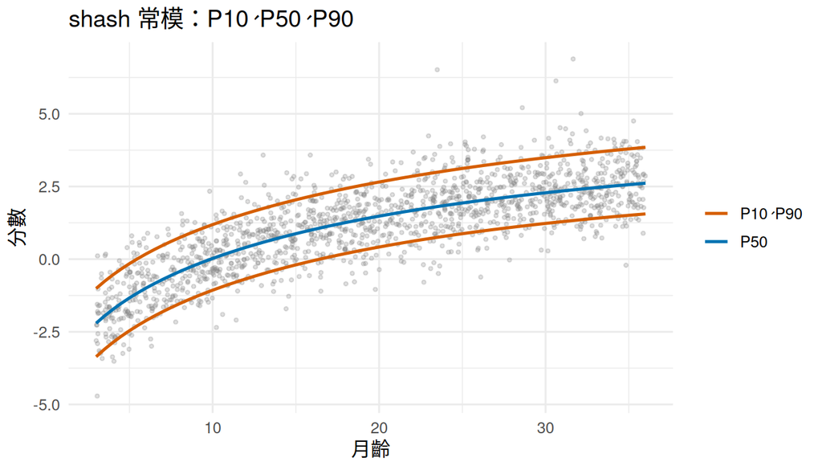

```r
curves |>
  pivot_longer(c(P10, P50, P90), names_to = "pct", values_to = "score") |>
  ggplot(aes(age_m, score)) +
  geom_point(aes(age, y), data = tibble(age, y), colour = "#7F7F7F", alpha = 0.25, size = 0.8) +
  geom_line(aes(group = pct, colour = pct == "P50"), linewidth = 0.9) +
  scale_colour_manual(values = c(`TRUE` = "#0072B2", `FALSE` = "#D55E00"),
                      labels = c(`TRUE` = "P50", `FALSE` = "P10、P90"), name = NULL) +
  labs(x = "月齡", y = "分數", title = "shash 常模：P10、P50、P90") +
  theme_minimal(base_size = 12)
```

## 9 0.24.0 的新東西

0.23.1 之後，只剩兩個地方還有手寫的導數。 0.24.0 把它們也交給 RTMB。

### 9.1 訊息的斜率：`information_slope()`

#### 公式

測驗訊息 $I(\theta) = \sum_i \mathrm{Var}_i(\theta)$。 它的斜率是三階中央動差的和（第 1 節的恆等式再微分一次）：

$$I'(\theta) = \sum_i \frac{d}{d\theta} \mathrm{Var}_i(\theta) = \sum_i M_{3,i}(\theta)$$

0.23.1 以前，kits 直接用右邊的公式。 0.24.0 只寫 $I(\theta)$（`tcc()` 的 `slope`），斜率由 RTMB 給。

#### 程式

```r
show_code("pcm_core.R", "information_slope")
# kits/R/pcm_core.R，第 64–69 行
# 測驗訊息的斜率 I'(theta)：只寫 I(theta)（tcc() 的 slope），導數由 RTMB 給。
# 每個 I 只和自己的 theta 有關，所以 sum(I) 的梯度就是每個 theta 的 I'
information_slope <- function(theta, parms, items) {
  tape <- RTMB::MakeTape(\(t) sum(tcc(t, parms, items)$slope), theta)
  drop(tape$jacobian(theta))
}
```

#### RTMB 做什麼

`MakeTape()` 把 $\sum_\theta I(\theta)$ 錄成 tape。 每個 $I$ 只和自己的 theta 有關，所以 `$jacobian()` 的每一個元素就是那個 theta 的 $I'$。

#### 對答案

第 4 節的示範資料校準（語言，M03）。

```r
its <- unique(parms$item_id)
theta_grid <- seq(-6, 6, by = 0.1)
slope <- kits:::information_slope(theta_grid, parms, its)
beta_by <- kits:::betas_by_item(parms)
m3 <- map(its, \(i) algo_pcm(theta_grid, beta_by[[i]], third = TRUE)$M3) |>
  reduce(`+`)
record("9", "I'(theta)：RTMB vs 三階中央動差的和", slope - m3)
```

```
#> [1] 1.776357e-15
```

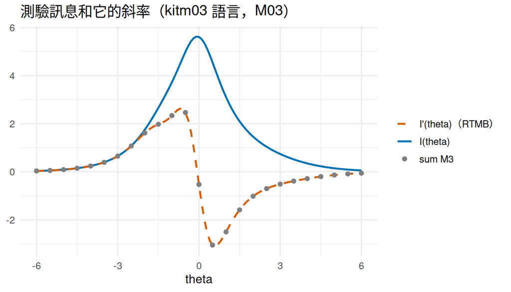

```r
info_df <- tibble(theta = theta_grid, info = kits:::tcc(theta_grid, parms, its)$slope,
                  slope = slope, m3 = m3)
ggplot(info_df, aes(theta)) +
  geom_line(aes(y = info, colour = "I(theta)"), linewidth = 0.9) +
  geom_line(aes(y = slope, colour = "I'(theta)（RTMB）"), linewidth = 0.9, linetype = "dashed") +
  geom_point(aes(y = m3, colour = "sum M3"), data = filter(info_df, row_number() %% 5 == 1)) +
  scale_colour_manual(values = c(`I(theta)` = "#0072B2", `I'(theta)（RTMB）` = "#D55E00",
                                 `sum M3` = "#7F7F7F"), name = NULL) +
  labs(x = "theta", y = NULL, title = "測驗訊息和它的斜率（kitm03 語言，M03）") +
  theme_minimal(base_size = 12)
```

灰點（三階中央動差的和）落在橘色虛線（RTMB 的斜率）上。

### 9.2 Goodman–Kruskal gamma 的 SE：`gk_gamma()`

#### 公式

`kits_item_restscore()`（Kreiner, 2011）比較題目分數和其餘分數的 gamma。 $n_a$ 是表格第 $a$ 格的次數。 $\pi^c_a$、$\pi^d_a$ 是和第 $a$ 格一致、不一致的格子的次數和：

$$C = \tfrac{1}{2}\sum_a n_a \pi^c_a, \qquad D = \tfrac{1}{2}\sum_a n_a \pi^d_a, \qquad
\gamma = \frac{C - D}{C + D}$$

delta method（多項分布）：

$$\mathrm{SE}^2 = \sum_a n_a J_a^2 - \left(\sum_a n_a J_a\right)^2, \qquad J_a = \frac{\partial\gamma}{\partial n_a}$$

0.23.1 以前，$J$ 用發表的公式（vcdExtra 的 `GKgamma()` 的 $\psi$）：

$$\psi_a = \frac{2\left(D \, \pi^c_a - C \, \pi^d_a\right)}{(C + D)^2}$$

0.24.0 只寫 $\gamma$，$J$ 由 RTMB 給。

#### 程式

```r
show_code("restscore.R", "gk_gamma")
# kits/R/restscore.R，第 138–156 行
# Goodman–Kruskal gamma 和它的漸近 SE（和 vcdExtra::GKgamma() 相同）。只寫 gamma，導數由 RTMB 給：
#   n：格子的次數（一格一個）；C、D：一致、不一致的配對數，C = n' K_C n / 2、D = n' K_D n / 2
#   （K_C[a, b] = 1：格子 a、b 的列和欄同方向不同；K_D：反方向）；gamma = (C - D) / (C + D)
#   delta method（多項分布）：SE^2 = sum n J^2 - (sum n J)^2，J = d gamma / d n
gk_gamma <- function(tab) {
  n <- as.vector(tab)
  K <- concordance_signs(nrow(tab), ncol(tab))
  gamma_of <- function(n) {
    C <- sum(n * drop((K > 0) %*% n)) / 2
    D <- sum(n * drop((K < 0) %*% n)) / 2
    (C - D) / (C + D)
  }
  C_plus_D <- sum(n * drop((K != 0) %*% n)) / 2
  if (!is.finite(C_plus_D) || C_plus_D <= 0) {
    return(list(gamma = NA_real_, se = NA_real_))
  }
  J <- drop(RTMB::MakeTape(gamma_of, n)$jacobian(n))
  list(gamma = gamma_of(n), se = sqrt(max(sum(n * J^2) - sum(n * J)^2, 0)))
}
```

#### RTMB 做什麼

$\gamma$ 寫成格子次數的函數 `gamma_of(n)`。 `MakeTape(gamma_of, n)$jacobian(n)` 就是 $J = \partial\gamma / \partial n$。 不用推 $\psi$。

#### 對答案

第 2 節的模擬資料：第 1 題的分數 × 其餘分數，只用答了五題的 300 人。

```r
full <- X[complete.cases(X), ]
tab <- table(rest = rowSums(full[, -1]), item = full[, "a1"])
gk <- kits:::gk_gamma(unclass(tab))
unlist(gk)
```

```
#>      gamma         se
#> 0.46013072 0.05521165
```

照 $\psi$ 的公式，用 base R 算一次。

```r
tab_n <- unclass(tab)
same_dir <- \(i, j) sum(tab_n[row(tab_n) < i & col(tab_n) < j]) +
  sum(tab_n[row(tab_n) > i & col(tab_n) > j])
oppo_dir <- \(i, j) sum(tab_n[row(tab_n) < i & col(tab_n) > j]) +
  sum(tab_n[row(tab_n) > i & col(tab_n) < j])
pi_c <- outer(seq_len(nrow(tab_n)), seq_len(ncol(tab_n)), Vectorize(same_dir))
pi_d <- outer(seq_len(nrow(tab_n)), seq_len(ncol(tab_n)), Vectorize(oppo_dir))
```

```r
C <- sum(tab_n * pi_c) / 2
D <- sum(tab_n * pi_d) / 2
psi <- 2 * (D * pi_c - C * pi_d) / (C + D)^2
se_psi <- sqrt(sum(tab_n * psi^2) - sum(tab_n * psi)^2)
record("9", "GK gamma：RTMB vs (C - D) / (C + D)", gk$gamma - (C - D) / (C + D))
```

```
#> [1] 0
```

```r
record("9", "GK gamma 的 SE：RTMB 的 J vs psi 公式", gk$se - se_psi)
```

```
#> [1] 0
```

## 10 數字怎麼驗證

### 10.1 這份文件的對答案

```r
checks |>
  mutate(max_diff = formatC(max_diff, format = "e", digits = 1)) |>
  rename(節 = section, 比較 = check, 最大差距 = max_diff) |>
  knitr::kable()
```

| 節 | 比較 | 最大差距 |
| --- | --- | --- |
| 1 | log S：advector 的路 vs 數值的路 | 2.2e-16 |
| 1 | d log S / d theta vs E | 4.4e-16 |
| 1 | d E / d theta vs Var | 6.1e-16 |
| 2 | CML 梯度：RTMB vs 中央差分 | 1.2e-08 |
| 3 | beta：fit_ad() vs kits_item() | 0.0e+00 |
| 3 | CML Hessian：RTMB vs 梯度的中央差分 | 6.5e-09 |
| 3 | SE_beta：A H^-1 A’ vs kits_item() | 0.0e+00 |
| 4 | WLE：牛頓法 vs kits_subj() | 0.0e+00 |
| 4 | WLE：kits_subj() vs optimize() | 2.5e-08 |
| 4 | WLE 的 SE：RTMB 的 I’ vs 中央差分 | 3.2e-01 |
| 5 | 門檻的 jacobian：RTMB vs 中央差分 | 2.8e-11 |
| 5 | thr_se：J V J’ vs kits_item() | 1.4e-17 |
| 6 | log gamma：algo_esf() vs 全部列舉 | 0.0e+00 |
| 6 | P(X_1 = x \| r = 3) vs 全部列舉 | 5.6e-17 |
| 6 | d log gamma / d beta vs -P(X >= g \| r) | 2.2e-16 |
| 7 | mu, sigma：kits vs base R optim() | 9.9e-08 |
| 7 | SE(mu)、SE(sigma)：sdreport() vs 數值 Hessian | 3.0e-08 |
| 8 | -log L：RTMB vs base R 的密度 | 2.3e-12 |
| 8 | 最大 \|梯度\|：RTMB vs 中央差分 | 9.9e-09 |
| 8 | 20 個月的密度積分 - 1 | 5.5e-12 |
| 9 | I’(theta)：RTMB vs 三階中央動差的和 | 1.8e-15 |
| 9 | GK gamma：RTMB vs (C - D) / (C + D) | 0.0e+00 |
| 9 | GK gamma 的 SE：RTMB 的 J vs psi 公式 | 0.0e+00 |

### 10.2 改版前後

0.23.1 把所有估計的導數交給 RTMB（`kits/NEWS.md` 的 0.23.1 一節）。 當時和 0.23.0 逐位比過：

- 校準（CML）、連結、常模：一個位元都不變。
- WLE 的 theta 和 SE：最多差約 1e-12（示範資料 6e-13；兩個模擬設計的 1,230 和 2,965 個組合，3e-13）。 例外是加權概似有兩個高點的情形：現在和 TAM 一樣，停在起始值走到的那一個。
- 門檻的 SE：最多差 5e-11（以前用中央差分）。
- 連結檢查的潛在常態：以前 `optim()` 停在梯度 1e-3 左右，所以平均和 SD 動了最多 7e-6；新的值 $-\log L$ 更低。

0.24.0 的兩個新地方（第 9 節）：

- 訊息的斜率：和三階中央動差的和差在 1e-12 以內（套件有測試檢查這個恆等式）。
- GK gamma 的 SE：不變（測試和 vcdExtra 的值比）。

### 10.3 和其他套件比

這份文件不重跑其他套件。 比較在另外幾份教學裡：

- kits、kitsPreview 和 TAM：同一份 KIT 語言資料，CML（kits）、dexter（kitsPreview）、TAM 的校準、門檻、WLE、原始分換算表和連結。
- kits 的演算法（`tutorial_algorithms/` 的六份，01 校準到 06 量尺）：每一步的公式、程式和對答案。
- kitsPreview 教學 第 8 節：kitsPreview 和 kits 的數字相同。

```r
render_time <- round(as.numeric(difftime(Sys.time(), t_start, units = "secs")), 1)
```

這份文件用 kits 0.24.2 和 RTMB 2.0 產生，所有程式跑了 8.7 秒。

## 參考文獻

Firth, D. (1993). Bias reduction of maximum likelihood estimates. *Biometrika, 80*(1), 27–38.

Jones, M. C., & Pewsey, A. (2009). Sinh-arcsinh distributions. *Biometrika, 96*(4), 761–780.

Kreiner, S. (2011). A note on item-restscore association in Rasch models. *Applied Psychological Measurement, 35*, 557–561.

Kristensen, K. (2024). RTMB: ‘R’ bindings for ‘TMB’. R package.

Magis, D. (2015). A note on weighted likelihood and Jeffreys modal estimation of proficiency levels in polytomous item response models. *Psychometrika, 80*(1), 200–204.

Masters, G. N. (1982). A Rasch model for partial credit scoring. *Psychometrika, 47*(2), 149–174.

Warm, T. A. (1989). Weighted likelihood estimation of ability in item response theory. *Psychometrika, 54*(3), 427–450.